# Creation of super regions

Martin Durocher

17/09/2019

## Introduction

The package `floodnetProject16` comes with a set of already selected gauged stations `gaugedSites` with unregulated stream for which the drainage area and the mean annual precipitation were available. These sites were also verified for the presence of trend or jump and have at least 20 years of data.

Pooled frequency analysis transfer information from nearby sites to a target site. Such pooling groups are formed according to a given measure of similarity and the idea of super regions was introduced to combine the information provided by more than one measure of similarity. Limiting the pooling frequency analysis to specific administrative regions, such as provinces, can as a form geographical super regions. The disavantage of this approach is that the boundary are not generally obtained according to relevant hydrological properties.

For delineating pooling groups, the Floodnet project recommend to use a measure of similarity based on to the seasonality of annual maximum discharges and to use super regions based on catchment descriptors. The datasets `gaugedSites` suggests two set of super regions. This document presents how they were obtained.

## Methodology

We consider two spaces where the similarity between sites can be represented. They are the geographical and physical space. The physical space has for coordinates the drainage area (AREA) and mean annual precipitation (MAP). In Canada, AREA and MAP can be used as surrogate for climate and scale. See Mostofi Zadeh and Burn for more details. The graphic below shows the 1114 gauged stations inside these two spaces.

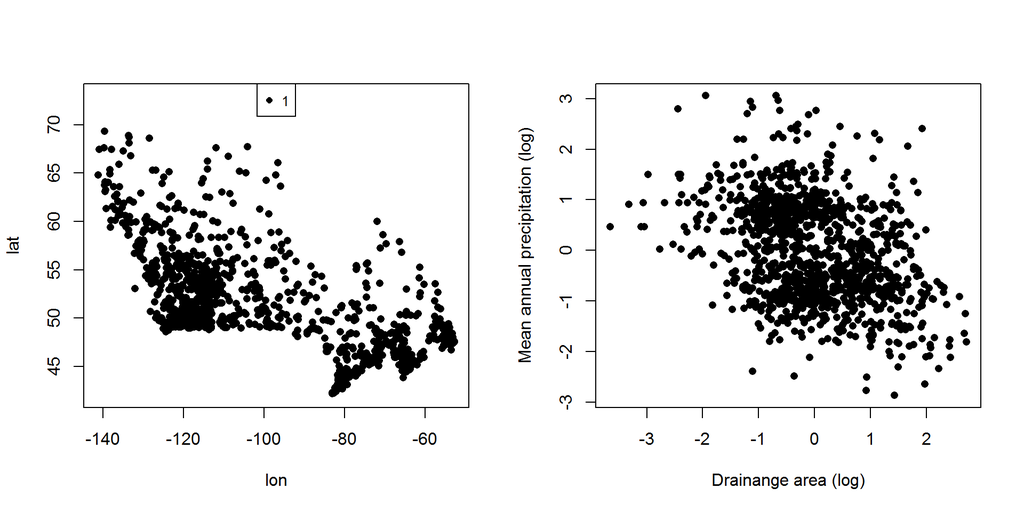

```r
library(floodnetProject16)
library(CSHShydRology)

xd <- scale(log(gaugedSites[,c('area','map')]))
coord <- gaugedSites[,c('lon','lat')]

## Generic function to plot the geographical and physical spaces.
myfig <- function(col = 'black', pch = 16){
  layout(matrix(c(1,2), 1,2))

  ucol <- sort(unique(col))

  plot(coord, pch = pch, col = col, ylim = c(42, 73))
  legend('top', horiz = TRUE,legend = seq_along(ucol), col = ucol, pch = pch, cex = .8)

  plot(xd, pch = pch, col = col,
         xlab = 'Drainange area (log)',
         ylab = 'Mean annual precipitation (log)')

}

myfig()
```

Hierarchical clustering techniques have often been used to delineate  
hydrologically homogenous regions. Using more specifically the Ward’s method, all sites are initially considered as their own cluster and are gradually paired up according to the similarity between clusters. This creates a tree structure that is used to form meaningful groups of sites. To create super regions, we consider the similarity based on the Euclidean distance between three descriptors: AREA, MAP and longitude (LON). The reason to include LON is to delineate super regions that are relatively compact in the geographical space. However, the latitude is not included because it is correlated to the seasonality of the annual maximum. Indeed the northern sites tend to be dominated by nival flood regime and have later spring freshets. This aspect is considered during the formation of the pooling group. For the purpose of this analysis, the logarithm of AREA and MAP is used. Additionally, the three variables are standardized to remove the scaling effect due to the unit of measurement.

## Results

The graphic below illustrates super regions defined by 6 clusters. We see that the super regions are relatively compact in both the geographical space and the physical space. One exception is the Pacific super region (3) in light green that is overlapping the South-East super region (5). Both have important annual precipitation, but are located near the opposite coasts. The North-East (2) and North-West (4) super regions correspond to the sites with the largest drainage areas. We also observe that the North-East super region receives more precipitation than the North-West super region. The two remaining clusters are the South-West super region (6) in red and a central super region (1) in light blue. The latter includes the basins with the smallest drainage areas (1) that does not correspond to a compact region in the geographical space.

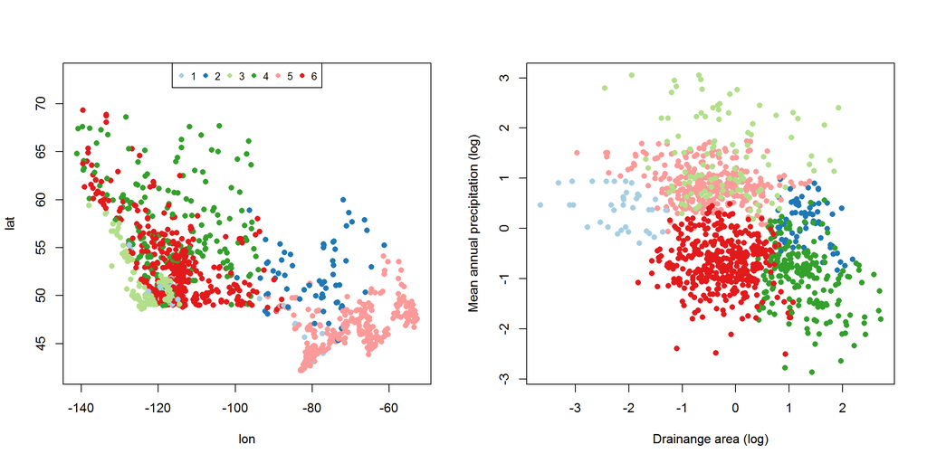

```r
## Set colors for displaying the clusters
mycol12 <- c('#a6cee3','#1f78b4','#b2df8a','#33a02c','#fb9a99','#e31a1c',
                         '#fdbf6f','#ff7f00','#cab2d6','#6a3d9a','#ffff99','#b15928')
palette(mycol12)

## Perform the classification
xd0 <- cbind(xd, scale(coord$lon))
hc <- hclust(dist(xd0), method = 'ward.D2')

## Identify 6 clusters
grp <- cutree(hc, k = 6)
grp <- order(order(table(grp)))[grp]

myfig(col = grp)
```

The same graphics are produced using this time 12 clusters, which further divided the previous ones. We see that the additional super region remains relatively compact in both spaces. The smallest super regions have 28 sites, which will be sufficient to create pooling groups of size 25, which is the size recommended by Floodnet.

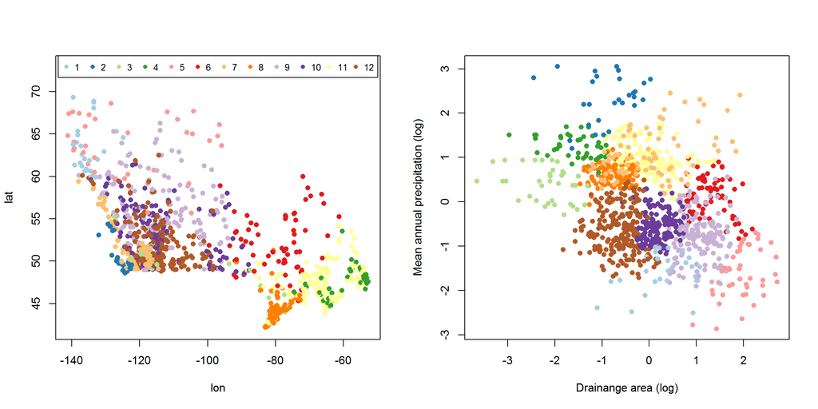

```r
## Identify 12 clusters
grp2 <- cutree(hc, k = 12)
grp2 <- order(order(table(grp2)))[grp2]

myfig(col = grp2)
```

## Conclusion

The present document showed how two sets of super regions were obtained using hierarchical clustering. These sets are the one saved in the datasets `gaugedSites`.

## References

- Mostofi Zadeh, S., & Burn, D. H. (2019). A Super Region Approach to Improve Pooled Flood Frequency Analysis. Canadian Water Resources Journal / Revue Canadienne Des Ressources Hydriques, 0(0), 1–14. https://doi.org/10.1080/07011784.2018.1548946